# Bayesian mixed models with brms | ROPE

Last updated: 2021-04-15

## ROPE

```r
fit_brm <- readRDS(file = "../stanout/brms_sim.rda")
beta <- posterior_samples(fit_brm, pars = "b_conditionb") %>% pull()
```

```r
length(beta)
```

```
[1] 4000
```

```r
beta[1:5]
```

```
[1] 26.169134 20.234850  9.773276 21.438894 12.943398
```

```r
quantile(beta, probs = c(.025, .5, .975))
```

```
      2.5%        50%      97.5%
-0.0991772 15.7370193 31.4614818
```

## ROPE

- Region of practical equivalence: range of values that are practically equivalent (Kruschke, 2010, 2011).
- Point values don’t represent our beliefs about what the null hypothesis is like: \(H_0 = 0\)
- The ROPE is the range of values that are practically equivalent to a null effect.
- Define region that is equivalent to no effect: all values in interval [-5, 5]

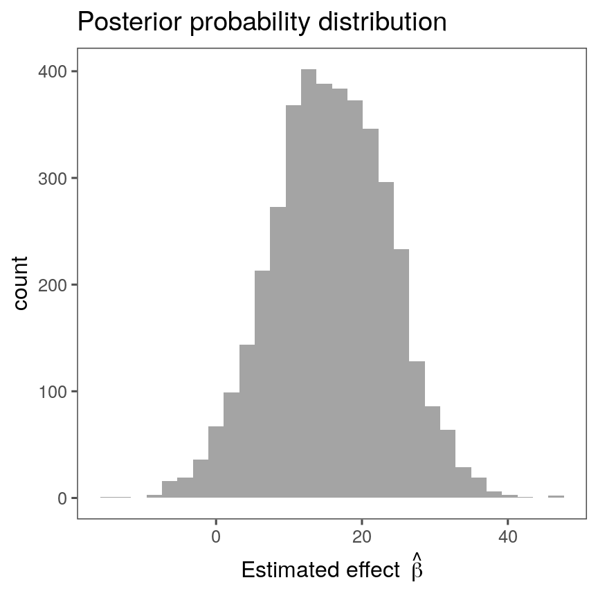

## ROPE

- Region of practical equivalence: range of values that are practically equivalent (Kruschke, 2010, 2011).
- Point values don’t represent our beliefs about what the null hypothesis is like: \(H_0 = 0\)
- The ROPE is the range of values that are practically equivalent to a null effect.
- Define region that is equivalent to no effect: all values in interval [-5, 5]

```r
library(bayestestR)
rope(beta, range = c(-5, 5))
```

```
# Proportion of samples inside the ROPE [-5.00, 5.00]:

inside ROPE
-----------
4.18 %
```

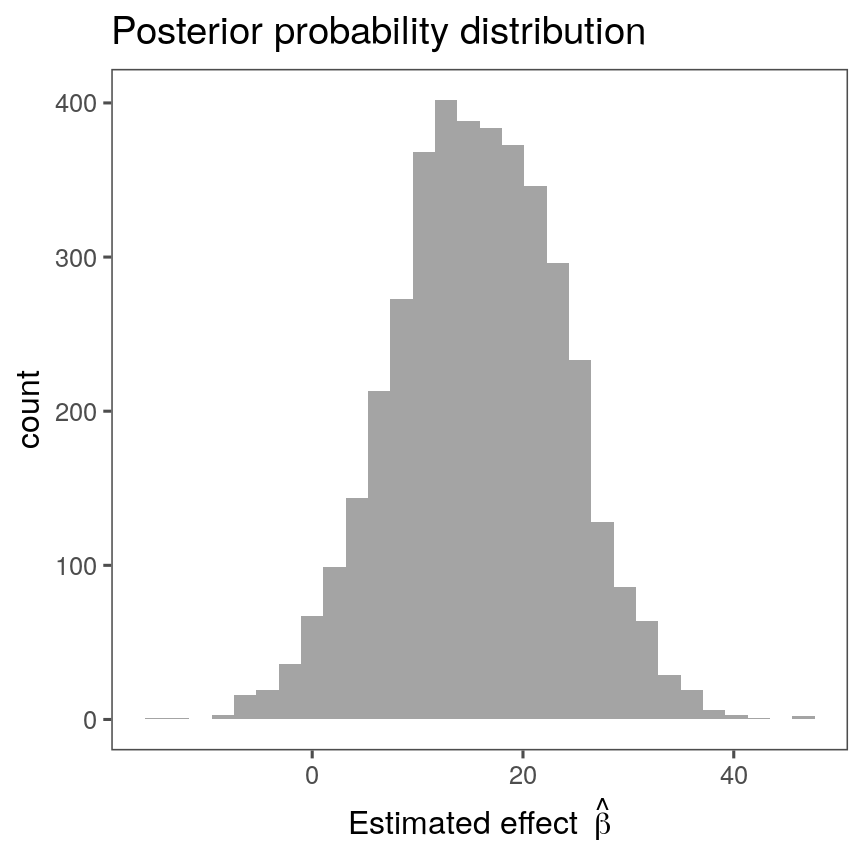

## ROPE

- Region of practical equivalence: range of values that are practically equivalent (Kruschke, 2010, 2011).
- Point values don’t represent our beliefs about what the null hypothesis is like: \(H_0 = 0\)
- The ROPE is the range of values that are practically equivalent to a null effect.
- Define region that is equivalent to no effect: all values in interval [-5, 5]

```r
library(bayestestR)
rope(beta, range = c(-5, 5))
```

```
# Proportion of samples inside the ROPE [-5.00, 5.00]:

inside ROPE
-----------
4.18 %
```

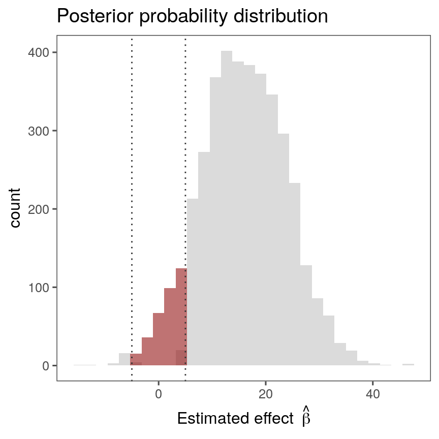

## ROPE

- Region of practical equivalence: range of values that are practically equivalent (Kruschke, 2010, 2011).
- Point values don’t represent our beliefs about what the null hypothesis is like: \(H_0 = 0\)
- The ROPE is the range of values that are practically equivalent to a null effect.
- Define region that is equivalent to no effect: all values in interval [-Inf, 5]

```r
library(bayestestR)
rope(beta, range = c(-Inf, 5))
```

```
# Proportion of samples inside the ROPE [-Inf, 5.00]:

inside ROPE
-----------
4.18 %
```

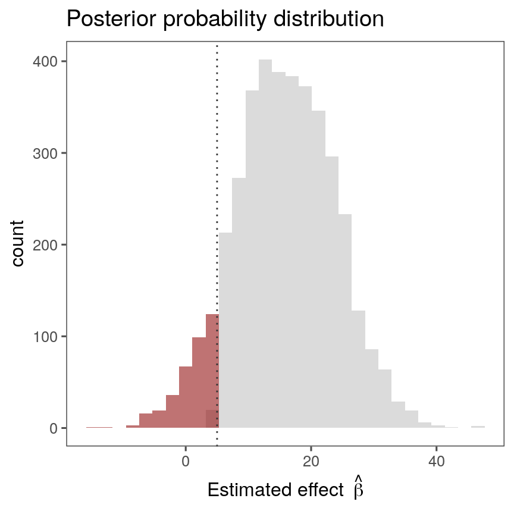

## ROPE

- Determine ROPE to assess the uncertainty of effect size (Makowski et al., 2019)
- Calculate the standardised effect size \(\delta\) from posterior: \(\delta = \frac{\beta}{\sigma}\)
- ROPE of [-0.1, 0.1] is the range of negligible effect sizes (Cohn, 1988; Kruschke, 2018).

## ROPE

- Determine ROPE to assess the uncertainty of effect size (Makowski et al., 2019)
- Calculate the standardised effect size \(\delta\) from posterior: \(\delta = \frac{\beta}{\sigma}\)
- ROPE of [-0.1, 0.1] is the range of negligible effect sizes (Cohn, 1988; Kruschke, 2018).

```r
sigma <- posterior_samples(fit_brm, pars = "sigma") %>% pull()
delta <- beta / sigma
```

```r
mean(delta) # small effect (see Cohen's d)
```

```
[1] 0.1584162
```

## ROPE

- Determine ROPE to assess the uncertainty of effect size (Makowski et al., 2019)
- Calculate the standardised effect size \(\delta\) from posterior: \(\delta = \frac{\beta}{\sigma}\)
- ROPE of [-0.1, 0.1] is the range of negligible effect sizes (Cohn, 1988; Kruschke, 2018).

```r
rope(delta, range = c(-0.1, 0.1))
```

```
# Proportion of samples inside the ROPE [-0.10, 0.10]:

inside ROPE
-----------
21.12 %
```

- The ROPE value indicates the extent to which the posterior cannot rule out a negligible effect.
- A meaningful effect size should have a small proportion of posterior samples within the ROPE.

## References

Cohn, J. (1988). *Statistical power analysis for the behavioral sciences*. Lawrence Earlbam Associates.

Kruschke, J. K. (2010). What to believe: Bayesian methods for data analysis. *Trends in Cognitive Sciences*, *14*(7), 293–300.

Kruschke, J. K. (2011). Bayesian assessment of null values via parameter estimation and model comparison. *Perspectives on Psychological Science*, *6*(3), 299–312.

Kruschke, J. K. (2018). Rejecting or accepting parameter values in Bayesian estimation. *Advances in Methods and Practices in Psychological Science*, *1*(2), 270–280.

Makowski, D., Ben-Shachar, M. S., & Lüdecke, D. (2019). bayestestR: Describing effects and their uncertainty, existence and significance within the Bayesian framework. *Journal of Open Source Software*, *4*(40), 1541.